# Lab: Churn prediction

Jimmy Azar

## Introduction

In this lab, we will build a classification model for predicting customer churn.

Our data consists of rows representing customers and columns representing features. The labels are in the column “churn” indicating those who unsubscribed within the last month. The features include services that customers signed up for as well as customer account info and demographic info.

## Data exploration

The data is provided in the file “churn.csv”. Read the file using `read.table()` and inspect the data (when using read.table make sure to specify if there is a header or not). How many observations and variables are there?

Check the data for any missing values (hint: `is.na()`). Use `which(..., arr.ind=TRUE)` to find out where these instances occur. Remove any customers (rows) that have a missing value or attribute. What is the size of the dataset now?

Find out how many levels (i.e. unique values) each column has (hint: you can use `apply()`, `unique()`, `length()`).

### Distribution by gender/internet service/payment method

How does the gender distribution look like in the dataset? Use `table()` to inspect the count of male and female customers in the data. Create a bar plot for this count (hint: `barplot(..., beside=TRUE)`). Is the dataset balanced in terms of gender?

What is the customer distribution in terms of internet service? Create a bar plot for the different levels of the attribute corresponding to internet service. What is the most common internet service?

Finally, repeat the previous exercise for payment method, i.e. generate a bar plot. What is the most common payment method?

## Feature transformation

Next, we need to prepare all features for building a predictive model. We can easily transform binary categorical features into binary numeric features (with values: 0 or 1). For continuous numeric features, we would need to normalize these by deducting the mean and dividing by the standard deviation. This would make the features comparable in scale.

### Binary and continuous features

Identify which features in the dataset are either binary or continuous. Extract a subset “df_tx” of the full data frame such that it includes only features that are either binary or continuous. Standardize those features that are continuous by removing their mean and dividing by the standard deviation. Also transform those features that are categorical binary into numeric binary features having values of 0 or 1 (hint: `as.numeric(as.factor(...)) - 1`).

Finally, for the standardized continuous features, check that their standard deviation is equal to 1.

### Multi-level categorical features

For the remaining features which are multi-level categorical we will apply one-hot-encoding to transform these into numeric values. For example, if one feature can take on 3 values/categories: A, B, and C, then this feature will be transformed into 3 numeric (binary) features, each indicating the presence (1) or absence (0) of the categories. Thus a value of A would correspond to [1,0,0], B to [0,1,0], and C to [0,0,1].

To implement one-hot-encoding, use `dummyVars()` (package: “caret”) as shown below to transform/encode the multi-level categorical features, and add the result to the previous data frame consisting of binary and continuous features.

```
library(caret)
df_categ <- df[,c("multiple_lines","internet_service","online_security","online_backup",
                  "device_protection","tech_support","streaming_tv","streaming_movies",
                  "contract","payment_method")]
dmy <- dummyVars(" ~ .", data = df_categ)
tmp <- data.frame(predict(dmy, newdata = df_categ))
df_tx <- cbind(df_tx,tmp)
```

## Train/test set

Create a training set, `train`, consisting of 70% of the original data; the remaining 30% goes into the test set, `test`; make sure your sampling is stratified (hint: you may use `sample.split()` of package “caTools”). Also, divide `train` and `test` into unlabeled training sets `trainD` and `testD` (respectively) and labels `trainL` and `testL` (respectively). Transform `trainD` and `testD` into matrices using `as.matrix()`. We are now ready to build a classifier.

## Artificial neural network

In this section we will set up a neural network classifier with Keras which is built on top of tensorflow, a python library. Note: you need to ensure you have a working python environment first (e.g. install miniconda before trying out the below).

```
install.packages("devtools")
devtools::install_github("rstudio/tensorflow")
library(tensorflow)
install_tensorflow()
#install_tensorflow(method = "conda") #first install miniconda2 in terminal

devtools::install_github("rstudio/keras")
library(keras)
install_keras()
#install_keras(method = "conda")
```

Build a neural network model with hidden layers containing 16 and 8 neurons with ReLu (rectified linear unit) activation function. The output layer is a single neuron with sigmoid activation function that maps into the range [0,1], similar to soft labels. We also select the adam algorithm which is a specialized gradient descent algorithm. Run the code below to set up the model and perform training.

```
model <- keras_model_sequential()
model %>%
  layer_dense(units = 16, kernel_initializer = "uniform", activation = "relu", input_shape=ncol(trainD)) %>%
  layer_dense(units = 8, kernel_initializer = "uniform", activation = "relu") %>%
  layer_dense(units = 1, kernel_initializer = "uniform", activation = "sigmoid") %>%
  compile(
    optimizer = "adam",
    loss      = "binary_crossentropy",
    metrics   = c("accuracy")
  )

history_log <- model %>% fit(
  trainD,
  trainL,
  epochs = 40, batch_size = 100,
  validation_split = 0.2
)
```

Compute the apparent error (i.e. in-sample error) and true test error (i.e out-of-sample error) by comparing the predicted labels with the actual labels found in `trainL` and `testL`.

[output not shown]

## Logistic classifier

In addition, we will also test a logistic classifier. Start by installing the packages “nnet” and “caret”. Then use the function `multinom()` to build the model.

```
library("nnet")
library("caret")
model = multinom(formula = churn ~., data = train)
```

The formula indicates that churn is the labels column and all remaining columns are features. Predict soft and hard labels for the test set using the following:

```
prob_predicted <- predict(object = model, newdata = testD, type = "probs")
cl <- predict(object = model, newdata = testD)
```

Finally generate the confusion matrix using the hard labels to assess the performance:

```
confusionMatrix(data = as.factor(cl),as.factor(testL))
```

## ROC/AUC

Using the predicted soft labels for the test set, we will generate an ROC curve and compute the area under the curve (AUC).

We need to create a variable threshold in [0,1] for the soft labels. For each threshold value, if the soft labels are greater than the threshold, the object is labeled as a “1” (churn), otherwise as a “0”. Thus at each threshold, we will obtain a false positive rate (FPR) and a true positive rate (TPR) by comparing the resulting (hard) labels with the true labels. To generate the ROC curve, we plot TPR vs. FPR.

The false positive rate on the x-axis is equivalent to (1-specificity) where specificity is the ratio of the number of correctly predicted negative labels (no churn) to the number of all true negative labels. The true positive rate is equivalent to sensitivity which is the ratio of the number of correctly predicted positive labels (churn) to the number of all true positive labels. Obtain values for the ROC curve yourself as described above without using an external library.

Plot the ROC curve and add the first bisector (y=x straight line) using:

`abline(a=0, b=1, col="gray", lty="dotted", lwd=2)`

Finally we need to compute the AUC value. Write a function to compute this area by summing up the areas of all trapezoids that make up the ROC curve. The area of a trapezium with bases A and B and height H is: (A+B)*H/2.

[output not shown]

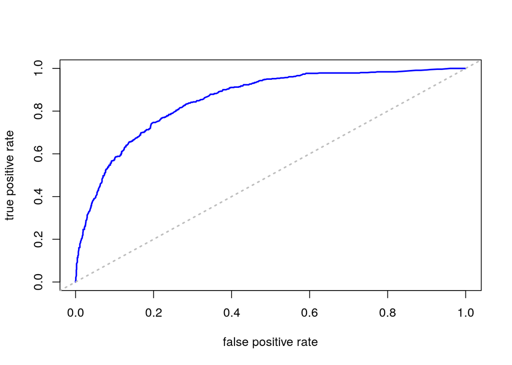

```
## [1] "AUC = 0.854799657993369"
```